# Project: Investigating Covid 19 data.

### Egypt summary

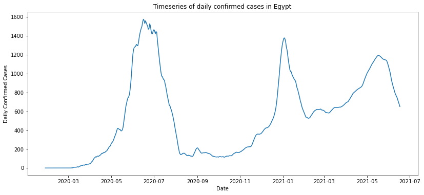

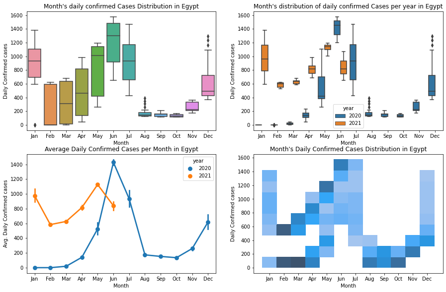

```python
country_summary(timeseries_df,"Egypt","daily_confirmed")
```

### Italy summary

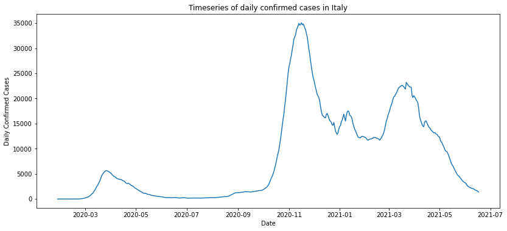

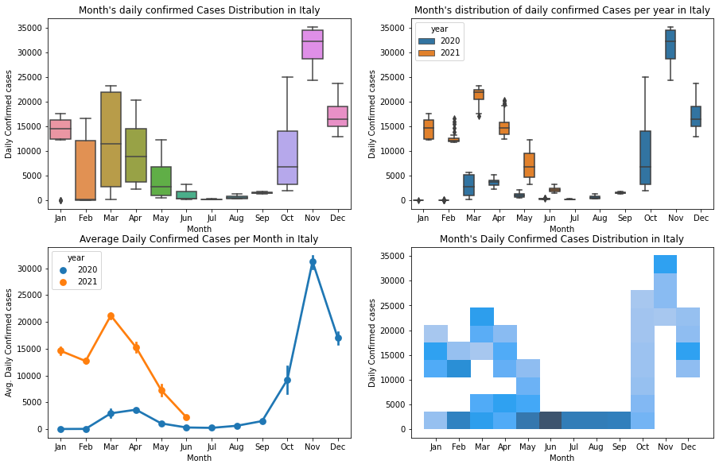

```python
country_summary(timeseries_df,"Italy","daily_confirmed")
```

### United Kingdom summary

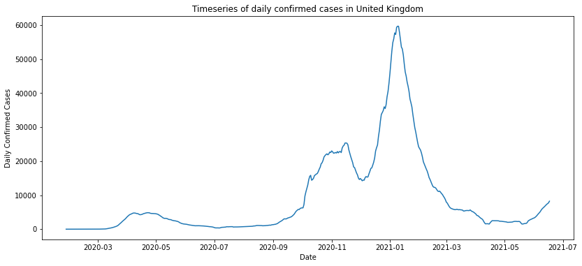

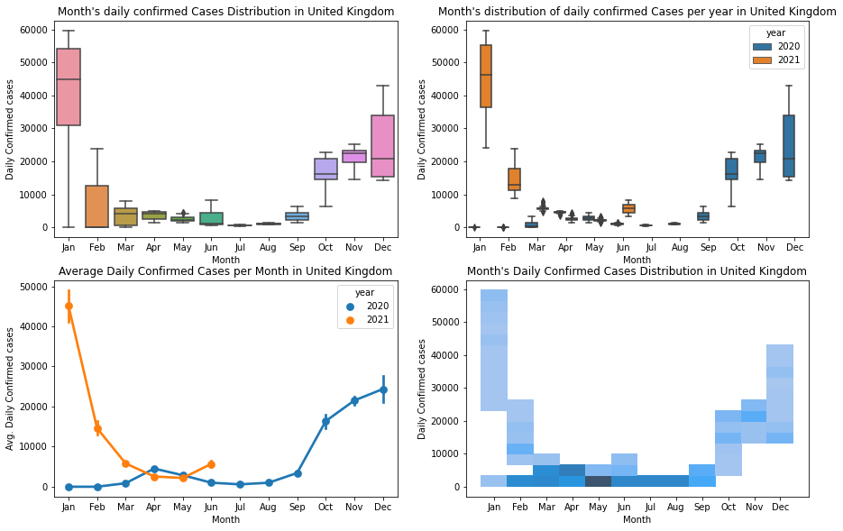

```python
country_summary(timeseries_df,"United Kingdom","daily_confirmed")
```

### India summary

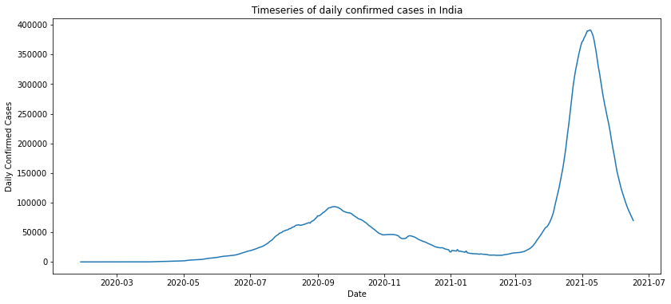

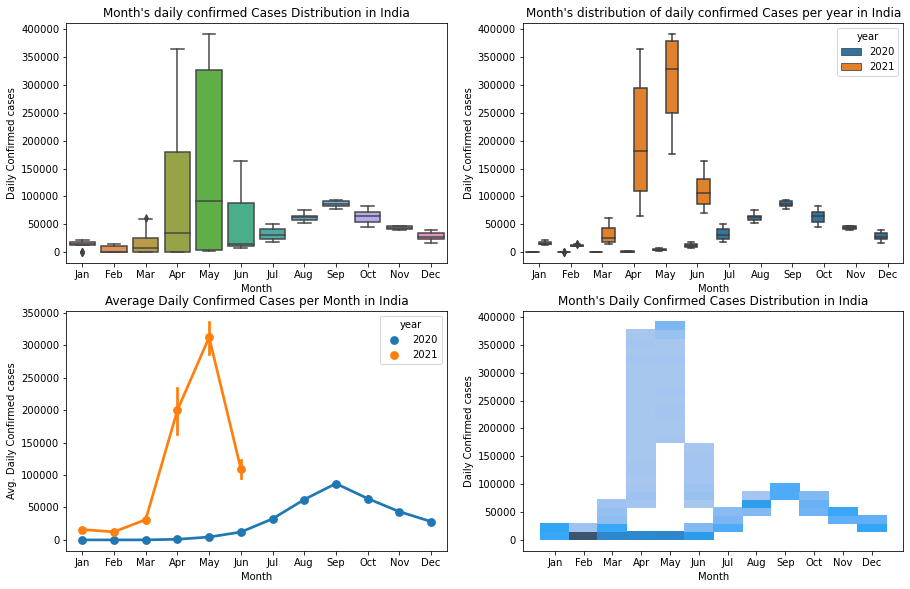

```python
country_summary(timeseries_df,"India","daily_confirmed")
```

# Conclusions

1- It is clear that the occurrence time of waves and their strength are greatly different from one country to another. We definitly can't identify a pattern that all countries follow either in wave strength or time of occurrence. we can only find few details that some countries share.

2- Worldwide data may be misleading if it took alone as different countries has very different conditions.So, we can't generalize any insights from it.

3- The strength of waves worldwide is continously incrasing but in Egypt,US and Italy the third wave is lower than the second one. This can explain point 2.

4- Egypt, United Kingdom and US shares a wave in months [Dec,Jan,Feb].

5- Egypt and Italy share a repetitive pattern of covid waves that starts between Feb and March. It happened in 2020 and also in 2021.

6- United Kingdom and India don't have waves in repeatitive patterns till now.

# Recommendation

Countries with repeatitive wave patterns should make great use of this. They should take proactive moves designing their future strategies about food imports,medcine, etc.. taking into consideration the reasonable likelihood of being hit by a wave on the next pattern.

# 5.2 Research Question 2

## How Can we rely on these data to make comparisons and extract conclusions?

we need to subdivide this question first

### 2.1 Do all countries have similar or close values for covid tests per million ratio?

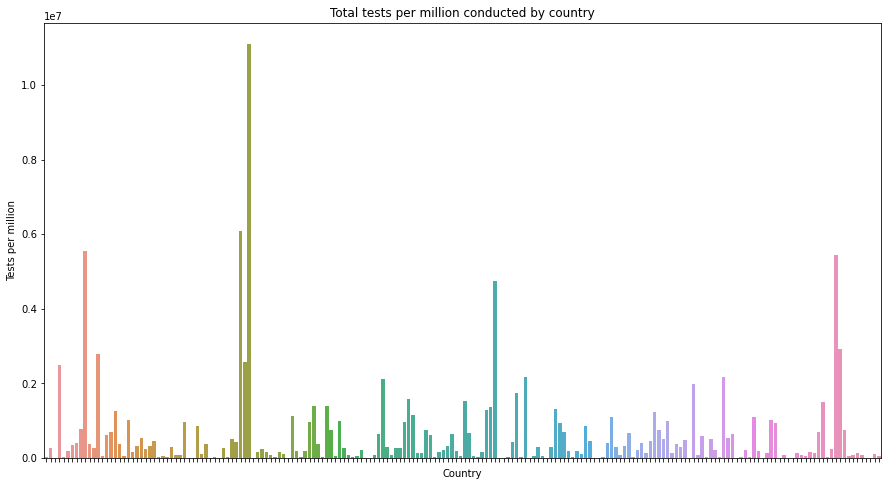

```python
plt.figure(figsize=(15,8))

test = sns.barplot(data = parameter_df ,y = "total_tests_per_million",x =np.arange(194) )
test.set(xticklabels=[]);
test.set(title='Total tests per million conducted by country')
test.set(xlabel="Country",ylabel="Tests per million");
```

# Observation

- We can see obviously that there is a wide gap of test rates between countries

### 2.2 Does tests per million ratio affect number of cases per million discoverd or cases discoverd per million ratio is a constant ratio that isn't affected by test rates?

## Plot Tests Per Million Vs. Average Daily Confirmed Cases Per Million

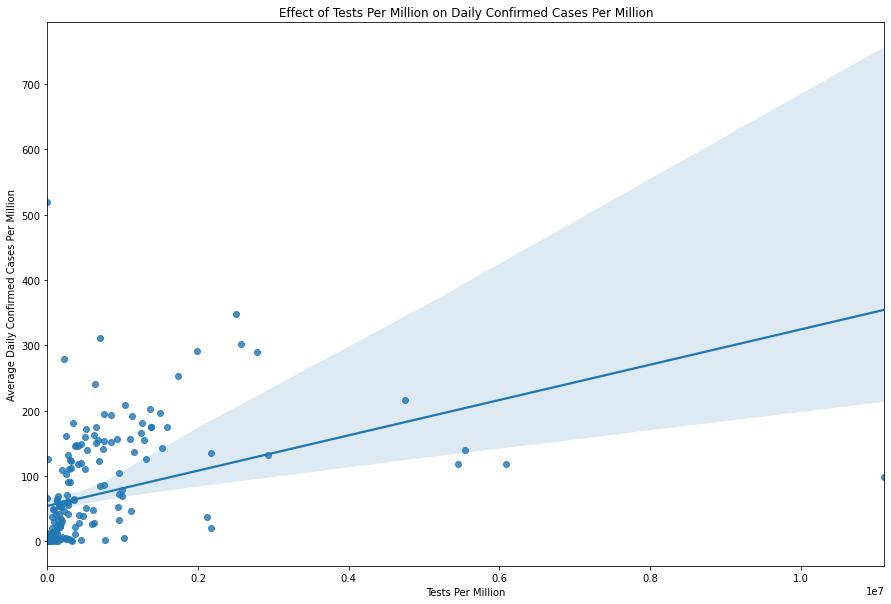

```python
plt.figure(figsize=(15,10))

sns.regplot(y = "Average_daily_cases_per_million",x = "total_tests_per_million", data = parameter_df)
plt.ylabel("Average Daily Confirmed Cases Per Million")
plt.xlabel("Tests Per Million");
plt.title("Effect of Tests Per Million on Daily Confirmed Cases Per Million");
```

## We need first to exclude outliers to make more accurate conclusion

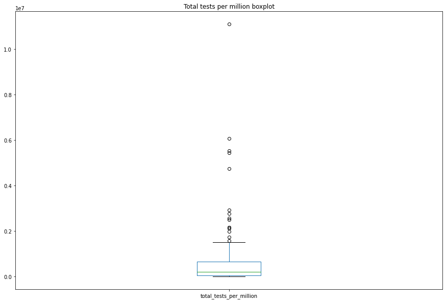

```python
# plot Total tests per million boxplot
plt.figure(figsize=(15,10))
parameter_df["total_tests_per_million"].plot(kind = "box");
plt.title("Total tests per million boxplot");
```

```python
#calculate upper_outlier_limit
Q1 =  np.percentile(parameter_df["total_tests_per_million"],25)
Q3 =  np.percentile(parameter_df["total_tests_per_million"],75)
IQR = Q3 -Q1
upper_outlier_limit = Q3 + 1.5*(IQR)
upper_outlier_limit
```

```
1570518.2694762493
```

```python
#Get data without outliers
nooutlier_df = parameter_df[parameter_df["total_tests_per_million"]<1570518.375].reset_index(drop = True).copy()
nooutlier_df
```

|  | country | continent | income_level | test_per_million_level | median_age_level | pop_density_level | population | pop_density | median_age | total_tests_per_million | Average_daily_confirmed | Average_daily_recoverd | Average_daily_deaths | Average_daily_full_vaccinated | Average_daily_cases_per_million | Average_daily_full_vaccinated_per_million | Average_Deaths_to_confirmed_ratio |
| --- | --- | --- | --- | --- | --- | --- | --- | --- | --- | --- | --- | --- | --- | --- | --- | --- | --- |
| 0 | Afghanistan | Asia | Low income | Low | Low | Low | 39770634.0 | 59.627 | 18.438 | 13893.115207 | 188.169591 | 122.218324 | 7.489279 | 345.547758 | 4.731370 | 8.688515 | 0.034584 |
| 1 | Albania | Europe | Upper middle income | High | High | High | 2874759.0 | 105.029 | 36.399 | 268638.171061 | 258.247563 | 253.206628 | 4.783626 | 685.093567 | 89.832770 | 238.313392 | 0.025465 |
| 2 | Algeria | Africa | Lower middle income | Low | Low | Low | 44612800.0 | 18.411 | 28.521 | 5174.770469 | 262.846004 | 182.906433 | 7.027290 | 0.000000 | 5.891717 | 0.000000 | 0.044140 |
| 3 | Angola | Africa | Lower middle income | Low | Low | Low | 33845950.0 | 26.363 | 16.677 | 17977.128726 | 72.688109 | 60.633528 | 1.658869 | 959.582846 | 2.147616 | 28.351482 | 0.038636 |
| 4 | Antigua and Barbuda | North America | High income | Low | High | High | 98711.0 | 222.564 | 33.976 | 169180.739735 | 2.461988 | 2.380117 | 0.081871 | 47.417154 | 24.941377 | 480.363425 | 0.042841 |
| ... | ... | ... | ... | ... | ... | ... | ... | ... | ... | ... | ... | ... | ... | ... | ... | ... | ... |
| 174 | Vietnam | Asia | Lower middle income | Low | High | High | 98183253.0 | 291.000 | 30.500 | 63986.645462 | 23.684211 | 9.070175 | 0.118908 | 175.113060 | 0.241225 | 1.783533 | 0.012815 |
| 175 | West Bank and Gaza | Asia | Lower middle income | Low | Low | High | 4817000.0 | 654.000 | 19.100 | 7790.948723 | 608.838207 | 594.941520 | 6.910331 | 0.000000 | 126.393649 | 0.000000 | 0.008184 |
| 176 | Yemen | Asia | Lower middle income | Low | Low | Low | 30457162.0 | 56.492 | 20.221 | 3022.343316 | 13.389864 | 7.485380 | 2.633528 | 0.000000 | 0.439629 | 0.000000 | 0.244270 |
| 177 | Zambia | Africa | Lower middle income | Low | Low | Low | 18877782.0 | 24.730 | 17.592 | 92780.550173 | 238.292398 | 198.606238 | 2.972710 | 12.115010 | 12.622902 | 0.641760 | 0.018326 |
| 178 | Zimbabwe | Africa | Lower middle income | Low | Low | Low | 15071278.0 | 38.420 | 18.668 | 40542.149113 | 79.779727 | 72.337232 | 3.210526 | 808.255361 | 5.293494 | 53.628854 | 0.045152 |

179 rows × 17 columns

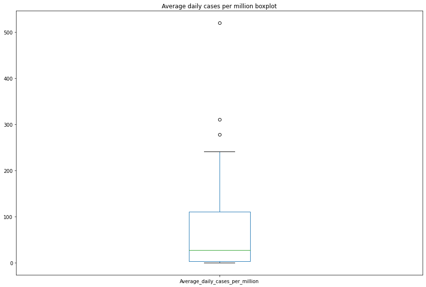

```python
plt.figure(figsize=(15,10))
nooutlier_df["Average_daily_cases_per_million"].plot(kind = "box");
plt.title("Average daily cases per million boxplot");
```

```python
Q1 = np.percentile(nooutlier_df["Average_daily_cases_per_million"],25)
Q3 = np.percentile(nooutlier_df["Average_daily_cases_per_million"],75)
IQR = Q3 -Q1
upper_outlier_limit = Q3 + 1.5*(IQR)
upper_outlier_limit
```

```
270.57073872801294
```

```python
nooutlier_df = nooutlier_df[nooutlier_df["Average_daily_cases_per_million"]<upper_outlier_limit]
```

## Plot Tests Per Million Vs. Average Daily Confirmed Cases Per Million

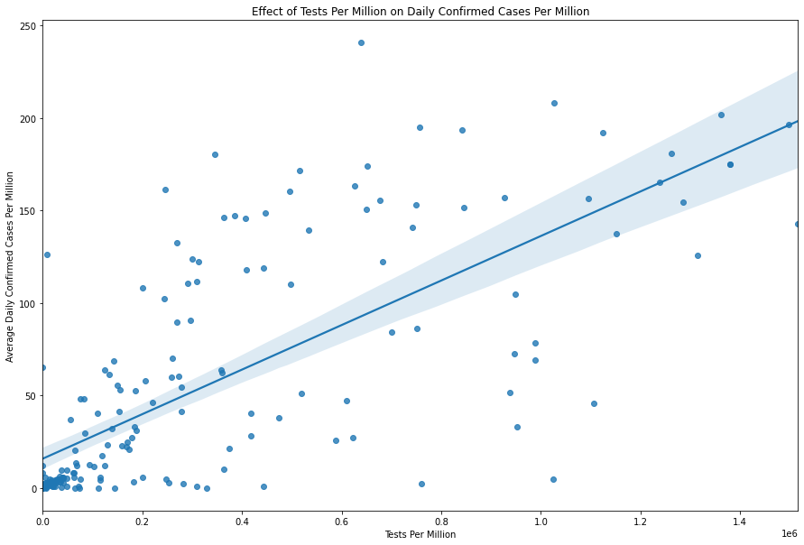

```python
plt.figure(figsize=(15,10))
sns.regplot(y = "Average_daily_cases_per_million",x = "total_tests_per_million", data = nooutlier_df)
plt.ylabel("Average Daily Confirmed Cases Per Million")
plt.xlabel("Tests Per Million");
plt.title("Effect of Tests Per Million on Daily Confirmed Cases Per Million");
```

# Observation

Tests Per Million and Average Daily Confirmed Cases Per Million are directly proportional. So, high test rates result in more new cases discovery.

## Plot Average Daily cases per million Vs. date for different test rates

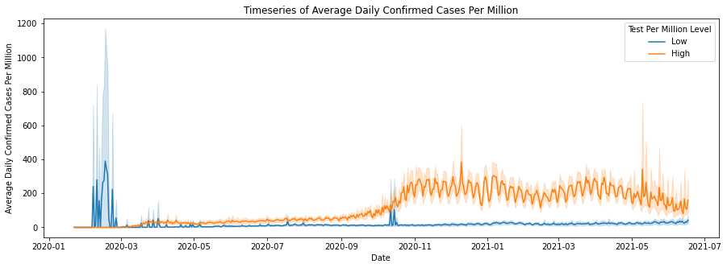

```python
plt.figure(figsize=(15,5))
sns.lineplot(data=timeseries_df,x="date",y="daily_cases_per_million",hue = "test_per_million_level")
plt.legend(title = "Test Per Million Level");
plt.ylabel("Average Daily Confirmed Cases Per Million")
plt.xlabel("Date");
plt.title("Timeseries of Average Daily Confirmed Cases Per Million");
```

# Conclusion

It is so clear that high test rates result in increase in daily cases per million ratio.

# Recommendation

we need to split our investigation of any parameter effect on daily cases into 2 levels.

1- Effect of the parameter on daily cases for high test rates

2- Effect of the parameter on daily cases for low test rates

So as not to get inaccurate observation due to interference between the parameter effect and high test rate effect. Finally, we can rely on the Effect of the parameter on daily cases for high test rates as the higher test rates, the more accurate data will be.

# 5.3 Research Question3

# What is the effect of Population density on daily cases?

### 1- Get rid of outliers first

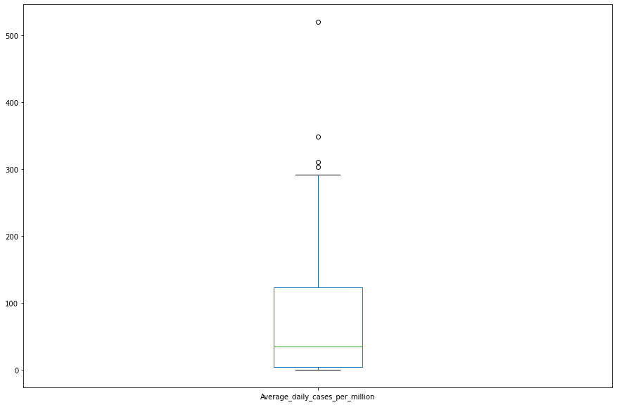

```python
plt.figure(figsize=(15,10))
parameter_df["Average_daily_cases_per_million"].plot(kind = "box");
```

```python
Q1 = np.percentile(parameter_df["Average_daily_cases_per_million"],25)
Q3 = np.percentile(parameter_df["Average_daily_cases_per_million"],75)
IQR = Q3 -Q1
upper_outlier_limit = Q3 + 1.5*(IQR)
upper_outlier_limit
```

```
302.4824030878897
```

```python
nooutliers_df = parameter_df[parameter_df["Average_daily_cases_per_million"]<upper_outlier_limit].reset_index(drop = True)
nooutliers_df
```

|  | country | continent | income_level | test_per_million_level | median_age_level | pop_density_level | population | pop_density | median_age | total_tests_per_million | Average_daily_confirmed | Average_daily_recoverd | Average_daily_deaths | Average_daily_full_vaccinated | Average_daily_cases_per_million | Average_daily_full_vaccinated_per_million | Average_Deaths_to_confirmed_ratio |
| --- | --- | --- | --- | --- | --- | --- | --- | --- | --- | --- | --- | --- | --- | --- | --- | --- | --- |
| 0 | Afghanistan | Asia | Low income | Low | Low | Low | 39770634.0 | 59.627 | 18.438 | 13893.115207 | 188.169591 | 122.218324 | 7.489279 | 345.547758 | 4.731370 | 8.688515 | 0.034584 |
| 1 | Albania | Europe | Upper middle income | High | High | High | 2874759.0 | 105.029 | 36.399 | 268638.171061 | 258.247563 | 253.206628 | 4.783626 | 685.093567 | 89.832770 | 238.313392 | 0.025465 |
| 2 | Algeria | Africa | Lower middle income | Low | Low | Low | 44612800.0 | 18.411 | 28.521 | 5174.770469 | 262.846004 | 182.906433 | 7.027290 | 0.000000 | 5.891717 | 0.000000 | 0.044140 |
| 3 | Angola | Africa | Lower middle income | Low | Low | Low | 33845950.0 | 26.363 | 16.677 | 17977.128726 | 72.688109 | 60.633528 | 1.658869 | 959.582846 | 2.147616 | 28.351482 | 0.038636 |
| 4 | Antigua and Barbuda | North America | High income | Low | High | High | 98711.0 | 222.564 | 33.976 | 169180.739735 | 2.461988 | 2.380117 | 0.081871 | 47.417154 | 24.941377 | 480.363425 | 0.042841 |
| ... | ... | ... | ... | ... | ... | ... | ... | ... | ... | ... | ... | ... | ... | ... | ... | ... | ... |
| 185 | Vietnam | Asia | Lower middle income | Low | High | High | 98183253.0 | 291.000 | 30.500 | 63986.645462 | 23.684211 | 9.070175 | 0.118908 | 175.113060 | 0.241225 | 1.783533 | 0.012815 |
| 186 | West Bank and Gaza | Asia | Lower middle income | Low | Low | High | 4817000.0 | 654.000 | 19.100 | 7790.948723 | 608.838207 | 594.941520 | 6.910331 | 0.000000 | 126.393649 | 0.000000 | 0.008184 |
| 187 | Yemen | Asia | Lower middle income | Low | Low | Low | 30457162.0 | 56.492 | 20.221 | 3022.343316 | 13.389864 | 7.485380 | 2.633528 | 0.000000 | 0.439629 | 0.000000 | 0.244270 |
| 188 | Zambia | Africa | Lower middle income | Low | Low | Low | 18877782.0 | 24.730 | 17.592 | 92780.550173 | 238.292398 | 198.606238 | 2.972710 | 12.115010 | 12.622902 | 0.641760 | 0.018326 |
| 189 | Zimbabwe | Africa | Lower middle income | Low | Low | Low | 15071278.0 | 38.420 | 18.668 | 40542.149113 | 79.779727 | 72.337232 | 3.210526 | 808.255361 | 5.293494 | 53.628854 | 0.045152 |

190 rows × 17 columns

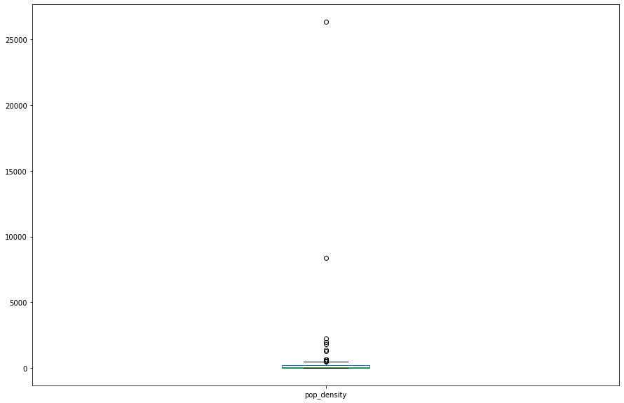

```python
plt.figure(figsize=(15,10))

nooutliers_df["pop_density"].plot(kind = "box");
```

```python
Q1 =  np.percentile(nooutliers_df["pop_density"],25)
Q3 = np.percentile(nooutliers_df["pop_density"],75)
IQR = Q3 -Q1
upper_outlier_limit = Q3 + 1.5*(IQR)
upper_outlier_limit
```

```
477.87962499999725
```

```python
nooutliers_df = nooutliers_df[nooutliers_df["pop_density"]<upper_outlier_limit].reset_index(drop = True)
nooutliers_df
```

|  | country | continent | income_level | test_per_million_level | median_age_level | pop_density_level | population | pop_density | median_age | total_tests_per_million | Average_daily_confirmed | Average_daily_recoverd | Average_daily_deaths | Average_daily_full_vaccinated | Average_daily_cases_per_million | Average_daily_full_vaccinated_per_million | Average_Deaths_to_confirmed_ratio |
| --- | --- | --- | --- | --- | --- | --- | --- | --- | --- | --- | --- | --- | --- | --- | --- | --- | --- |
| 0 | Afghanistan | Asia | Low income | Low | Low | Low | 39770634.0 | 59.627 | 18.438 | 13893.115207 | 188.169591 | 122.218324 | 7.489279 | 345.547758 | 4.731370 | 8.688515 | 0.034584 |
| 1 | Albania | Europe | Upper middle income | High | High | High | 2874759.0 | 105.029 | 36.399 | 268638.171061 | 258.247563 | 253.206628 | 4.783626 | 685.093567 | 89.832770 | 238.313392 | 0.025465 |
| 2 | Algeria | Africa | Lower middle income | Low | Low | Low | 44612800.0 | 18.411 | 28.521 | 5174.770469 | 262.846004 | 182.906433 | 7.027290 | 0.000000 | 5.891717 | 0.000000 | 0.044140 |
| 3 | Angola | Africa | Lower middle income | Low | Low | Low | 33845950.0 | 26.363 | 16.677 | 17977.128726 | 72.688109 | 60.633528 | 1.658869 | 959.582846 | 2.147616 | 28.351482 | 0.038636 |
| 4 | Antigua and Barbuda | North America | High income | Low | High | High | 98711.0 | 222.564 | 33.976 | 169180.739735 | 2.461988 | 2.380117 | 0.081871 | 47.417154 | 24.941377 | 480.363425 | 0.042841 |
| ... | ... | ... | ... | ... | ... | ... | ... | ... | ... | ... | ... | ... | ... | ... | ... | ... | ... |
| 169 | Venezuela | South America | Lower middle income | Low | Low | Low | 28358019.0 | 32.238 | 29.600 | 118450.234482 | 500.705653 | 461.955166 | 5.664717 | 296.093567 | 17.656581 | 10.441264 | 0.012480 |
| 170 | Vietnam | Asia | Lower middle income | Low | High | High | 98183253.0 | 291.000 | 30.500 | 63986.645462 | 23.684211 | 9.070175 | 0.118908 | 175.113060 | 0.241225 | 1.783533 | 0.012815 |
| 171 | Yemen | Asia | Lower middle income | Low | Low | Low | 30457162.0 | 56.492 | 20.221 | 3022.343316 | 13.389864 | 7.485380 | 2.633528 | 0.000000 | 0.439629 | 0.000000 | 0.244270 |
| 172 | Zambia | Africa | Lower middle income | Low | Low | Low | 18877782.0 | 24.730 | 17.592 | 92780.550173 | 238.292398 | 198.606238 | 2.972710 | 12.115010 | 12.622902 | 0.641760 | 0.018326 |
| 173 | Zimbabwe | Africa | Lower middle income | Low | Low | Low | 15071278.0 | 38.420 | 18.668 | 40542.149113 | 79.779727 | 72.337232 | 3.210526 | 808.255361 | 5.293494 | 53.628854 | 0.045152 |

174 rows × 17 columns

### Figure relationship between Daily cases and Population Density for both Tests per Million levels.

[figure not shown]

```python
g = sns.FacetGrid(nooutliers_df, col="test_per_million_level", height=5, aspect=1,
                  sharey=True)
g.map(sns.regplot, "pop_density", "Average_daily_cases_per_million" )
for ax, title in zip(g.axes.flat, ['Low Tests per Million', 'High Tests per Million']):
    ax.set_title(title)
for ax, xlabel in zip(g.axes.flat, ['Low Tests per Million', 'High Tests per Million']):
    ax.set_xlabel("Population Density (People / Km2)")
    ax.set_ylabel("Average Daily confirmed cases per million")
for ax in g.axes.ravel():
    ax.set_xticklabels(ax.get_xticklabels());
```

[figure not shown]

```python
g = sns.FacetGrid(timeseries_df, col="test_per_million_level",hue ="pop_density_level", height=5, aspect=1.5,
                  sharey=True)
g.map(sns.lineplot, "date", "daily_cases_per_million" )
plt.legend(title = "Population Density Level")
for ax in g.axes.ravel():
    ax.set_xticklabels(ax.get_xticklabels(), rotation=90);
    ax.set_ylim(0,1000);
for ax, title in zip(g.axes.flat, ['Low Tests per Million', 'High Tests per Million']):
    ax.set_title(title)
for ax, xlabel in zip(g.axes.flat, ['Low Tests per Million', 'High Tests per Million']):
    ax.set_xlabel("Date")
    ax.set_ylabel("Average Daily confirmed cases per million")
```

# Observation

1- For low test rates it seems to have no effect.

2- For high test rates we can see an increase in average daily cases per million for high population density.

# 5.4 Research Question4

# What is the effect of median age on daily cases?

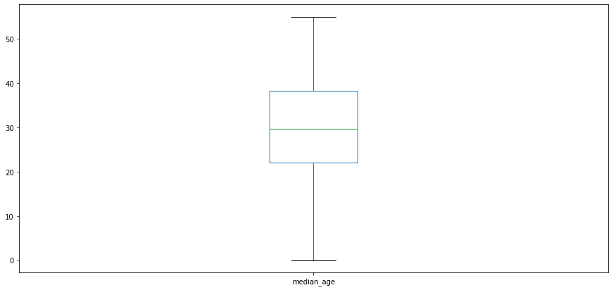

```python
plt.figure(figsize=(15,7))
parameter_df["median_age"].plot(kind = "box");
```

```python
parameter_df["median_age"].describe()
```

```
count    194.000000
mean      30.310169
std        9.482776
min        0.000000
25%       21.960000
50%       29.710500
75%       38.298000
max       55.000000
Name: median_age, dtype: float64
```

### We got wrong value of zero as min, lets investigate this.

```python
parameter_df.sort_values(by = "median_age")
```

|  | country | continent | income_level | test_per_million_level | median_age_level | pop_density_level | population | pop_density | median_age | total_tests_per_million | Average_daily_confirmed | Average_daily_recoverd | Average_daily_deaths | Average_daily_full_vaccinated | Average_daily_cases_per_million | Average_daily_full_vaccinated_per_million | Average_Deaths_to_confirmed_ratio |
| --- | --- | --- | --- | --- | --- | --- | --- | --- | --- | --- | --- | --- | --- | --- | --- | --- | --- |
| 105 | MS Zaandam | ship | Low income | Low | Low | High | 1432.0 | 187.181 | 0.000 | 0.000000e+00 | 0.017544 | 0.013645 | 0.003899 | 0.000000 | 12.251299 | 0.000000 | 0.220234 |
| 128 | Niger | Africa | Low income | Low | Low | Low | 25045000.0 | 19.110 | 15.151 | 4.547375e+03 | 10.637427 | 10.093567 | 0.376218 | 0.000000 | 0.424733 | 0.000000 | 0.047441 |
| 110 | Mali | Africa | Low income | Low | Low | Low | 20810156.0 | 16.596 | 16.347 | 1.491599e+04 | 28.000000 | 19.495127 | 1.019493 | 82.146199 | 1.345497 | 3.947409 | 0.044564 |
| 34 | Chad | Africa | Low income | Low | Low | Low | 16877855.0 | 13.045 | 16.554 | 7.327412e+03 | 9.637427 | 9.294347 | 0.339181 | 0.000000 | 0.571010 | 0.000000 | 0.054227 |
| 4 | Angola | Africa | Lower middle income | Low | Low | Low | 33845950.0 | 26.363 | 16.677 | 1.797713e+04 | 72.688109 | 60.633528 | 1.658869 | 959.582846 | 2.147616 | 28.351482 | 0.038636 |
| ... | ... | ... | ... | ... | ... | ... | ... | ... | ... | ... | ... | ... | ... | ... | ... | ... | ... |
| 141 | Portugal | Europe | High income | High | High | High | 10167955.0 | 111.330 | 46.158 | 1.238997e+06 | 1679.586745 | 1594.062378 | 33.249513 | 4904.672515 | 165.184321 | 482.365679 | 0.024496 |
| 3 | Andorra | Europe | High income | High | High | High | 77384.0 | 164.394 | 46.200 | 2.501745e+06 | 26.976608 | 26.588694 | 0.247563 | 32.000000 | 348.607053 | 413.522175 | 0.027189 |
| 85 | Italy | Europe | High income | High | High | High | 60375868.0 | 205.555 | 47.288 | 1.151382e+06 | 8284.122807 | 7843.970760 | 247.933723 | 29237.444444 | 137.209171 | 484.257128 | 0.075426 |
| 87 | Japan | Asia | High income | Low | High | High | 126101993.0 | 346.934 | 48.358 | 1.244893e+05 | 1522.886940 | 1442.606238 | 27.830409 | 15836.284600 | 12.076629 | 125.583143 | 0.023058 |
| 118 | Monaco | Europe | High income | High | High | High | 39510.0 | 26338.255 | 55.000 | 1.314933e+06 | 4.961014 | 4.820663 | 0.064327 | 29.491228 | 125.563494 | 746.424401 | 0.018493 |

194 rows × 17 columns

```python
# replace wrong value with nan.
parameter_df["median_age"].replace(0,np.nan,inplace = True)
```

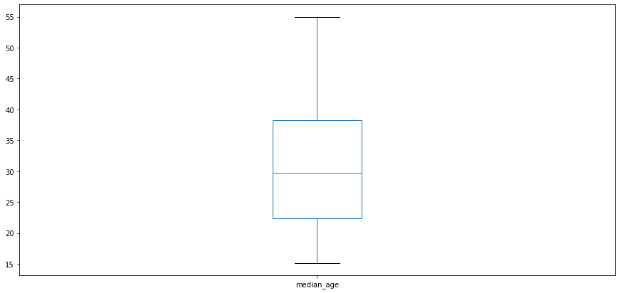

```python
#check
plt.figure(figsize=(15,7))
parameter_df["median_age"].plot(kind = "box");
```

### Right values with no outliers

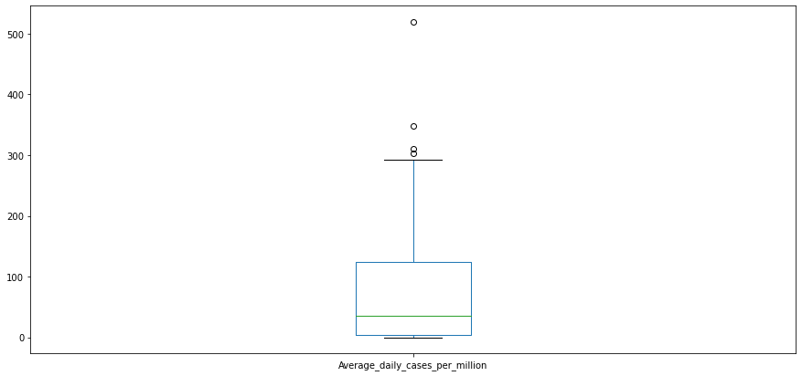

```python
# Average_daily_cases_per_million check
plt.figure(figsize=(15,7))
parameter_df["Average_daily_cases_per_million"].plot(kind = "box");
```

```python
Q1 = np.percentile(parameter_df["Average_daily_cases_per_million"],25)
Q3 = np.percentile(parameter_df["Average_daily_cases_per_million"],75)
IQR = Q3 -Q1
upper_outlier_limit = Q3 + 1.5*(IQR)
upper_outlier_limit
```

```
302.4824030878897
```

```python
nooutliers_df = parameter_df[parameter_df["Average_daily_cases_per_million"]<upper_outlier_limit].reset_index(drop = True)
nooutliers_df
```

|  | country | continent | income_level | test_per_million_level | median_age_level | pop_density_level | population | pop_density | median_age | total_tests_per_million | Average_daily_confirmed | Average_daily_recoverd | Average_daily_deaths | Average_daily_full_vaccinated | Average_daily_cases_per_million | Average_daily_full_vaccinated_per_million | Average_Deaths_to_confirmed_ratio |
| --- | --- | --- | --- | --- | --- | --- | --- | --- | --- | --- | --- | --- | --- | --- | --- | --- | --- |
| 0 | Afghanistan | Asia | Low income | Low | Low | Low | 39770634.0 | 59.627 | 18.438 | 13893.115207 | 188.169591 | 122.218324 | 7.489279 | 345.547758 | 4.731370 | 8.688515 | 0.034584 |
| 1 | Albania | Europe | Upper middle income | High | High | High | 2874759.0 | 105.029 | 36.399 | 268638.171061 | 258.247563 | 253.206628 | 4.783626 | 685.093567 | 89.832770 | 238.313392 | 0.025465 |
| 2 | Algeria | Africa | Lower middle income | Low | Low | Low | 44612800.0 | 18.411 | 28.521 | 5174.770469 | 262.846004 | 182.906433 | 7.027290 | 0.000000 | 5.891717 | 0.000000 | 0.044140 |
| 3 | Angola | Africa | Lower middle income | Low | Low | Low | 33845950.0 | 26.363 | 16.677 | 17977.128726 | 72.688109 | 60.633528 | 1.658869 | 959.582846 | 2.147616 | 28.351482 | 0.038636 |
| 4 | Antigua and Barbuda | North America | High income | Low | High | High | 98711.0 | 222.564 | 33.976 | 169180.739735 | 2.461988 | 2.380117 | 0.081871 | 47.417154 | 24.941377 | 480.363425 | 0.042841 |
| ... | ... | ... | ... | ... | ... | ... | ... | ... | ... | ... | ... | ... | ... | ... | ... | ... | ... |
| 185 | Vietnam | Asia | Lower middle income | Low | High | High | 98183253.0 | 291.000 | 30.500 | 63986.645462 | 23.684211 | 9.070175 | 0.118908 | 175.113060 | 0.241225 | 1.783533 | 0.012815 |
| 186 | West Bank and Gaza | Asia | Lower middle income | Low | Low | High | 4817000.0 | 654.000 | 19.100 | 7790.948723 | 608.838207 | 594.941520 | 6.910331 | 0.000000 | 126.393649 | 0.000000 | 0.008184 |
| 187 | Yemen | Asia | Lower middle income | Low | Low | Low | 30457162.0 | 56.492 | 20.221 | 3022.343316 | 13.389864 | 7.485380 | 2.633528 | 0.000000 | 0.439629 | 0.000000 | 0.244270 |
| 188 | Zambia | Africa | Lower middle income | Low | Low | Low | 18877782.0 | 24.730 | 17.592 | 92780.550173 | 238.292398 | 198.606238 | 2.972710 | 12.115010 | 12.622902 | 0.641760 | 0.018326 |
| 189 | Zimbabwe | Africa | Lower middle income | Low | Low | Low | 15071278.0 | 38.420 | 18.668 | 40542.149113 | 79.779727 | 72.337232 | 3.210526 | 808.255361 | 5.293494 | 53.628854 | 0.045152 |

190 rows × 17 columns

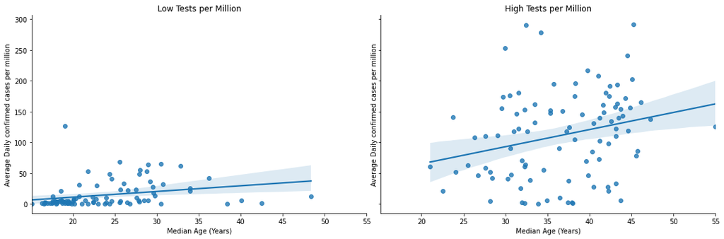

```python
g = sns.FacetGrid(nooutliers_df, col="test_per_million_level", height=5, aspect=1.5,
                  sharey=True)
g.map(sns.regplot, "median_age", "Average_daily_cases_per_million" )
for ax, title in zip(g.axes.flat, ['Low Tests per Million', 'High Tests per Million']):
    ax.set_title(title)
for ax, xlabel in zip(g.axes.flat, ['Low Tests per Million', 'High Tests per Million']):
    ax.set_xlabel("Median Age (Years)")
    ax.set_ylabel("Average Daily confirmed cases per million")
for ax in g.axes.ravel():
    ax.set_xticklabels(ax.get_xticklabels());
```

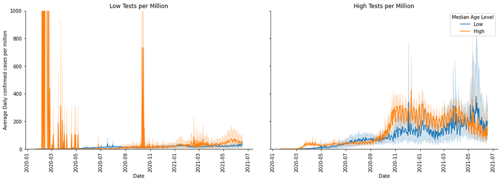

```python
g = sns.FacetGrid(timeseries_df, col="test_per_million_level",hue ="median_age_level", height=5, aspect=1.5,
                  sharey=True)
g.map(sns.lineplot, "date", "daily_cases_per_million" )
plt.legend(title = "Median Age Level")
for ax in g.axes.ravel():
    ax.set_xticklabels(ax.get_xticklabels(), rotation=90)
    ax.set_ylim(0,1000);
for ax, title in zip(g.axes.flat, ['Low Tests per Million', 'High Tests per Million']):
    ax.set_title(title)
for ax, xlabel in zip(g.axes.flat, ['Low Tests per Million', 'High Tests per Million']):
    ax.set_xlabel("Date")
    ax.set_ylabel("Average Daily confirmed cases per million")
```

# Observation

1- For both low test rates and high test rates we can see an increase in average daily cases per million with increasing median age but it is more clear for high test rates.

# Putting another variable in the picture

# Combine Effect of Median age with population density

### Effect of Median age on daily cases per million

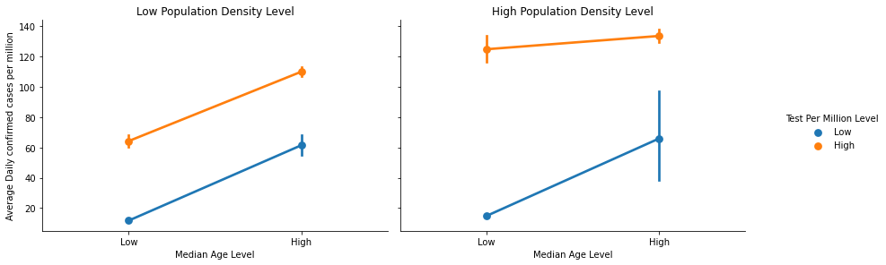

```python
g = sns.catplot(col = "pop_density_level",
            y = "daily_cases_per_million",
            hue= "test_per_million_level",
            x= "median_age_level",
            data = timeseries_df,
            kind = "point",
            split = True,
           margin_titles=True,height=4,aspect=1.5);
g.set_ylabels('Average Daily confirmed cases per million', fontsize=10);
g.set_xlabels('Median Age Level', fontsize=10);
g._legend.set_title("Test Per Million Level");
for ax, title in zip(g.axes.flat, ['Low Population Density Level', 'High Population Density Level']):
    ax.set_title(title)
```

# Observation

1- As concluded before high test rates results in more cases discovery than low test rates.

2- Countries with higher median age are experiencing higher number of cases. This can be shown for either high and low test rates but the effect is not so big for high population density countries with high test rates.

### Effect of Poulation density on daily cases per million

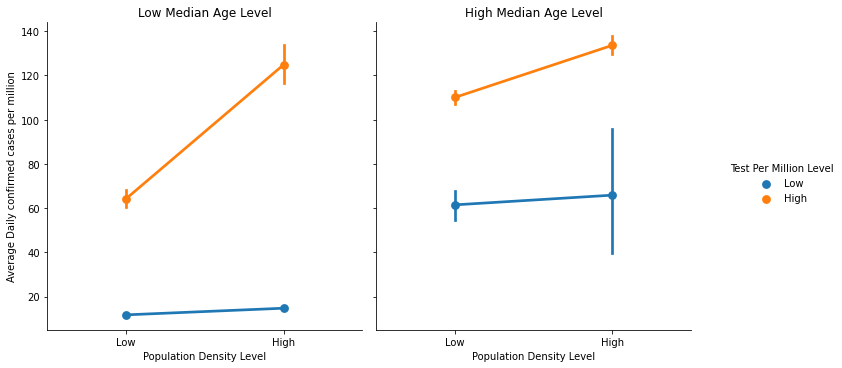

```python
g = sns.catplot(x = "pop_density_level",
            y = "daily_cases_per_million",
            hue= "test_per_million_level",
            col= "median_age_level",
            data = timeseries_df,
            kind = "point",
           split = True,
           margin_titles=True);
g.set_ylabels('Average Daily confirmed cases per million', fontsize=10);
g.set_xlabels('Population Density Level', fontsize=10);
g._legend.set_title("Test Per Million Level");
for ax, title in zip(g.axes.flat, ['Low Median Age Level', 'High Median Age Level']):
    ax.set_title(title)
```

# Observation

1- Again and as concluded before high test rates results in more cases discovery than low test rates.

2- Countries with high test rates are experiencing high number of cases with increasing population density.

3 - For Countries with low test rates:

```
a) With low median age level: there is no difference shown.
b) With high median age level: there is nearly no difference in average cases but the variance of number of      cases for high population density cases is grater.
```

### Effect of Poulation density and Median age on daily deaths per million

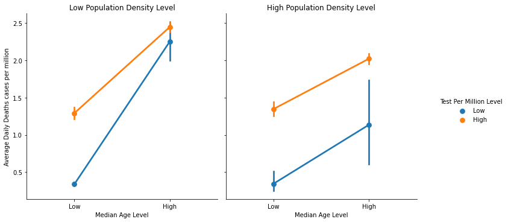

```python
g = sns.catplot(x = "median_age_level",
            y = "daily_deaths_per_million",
            hue= "test_per_million_level",
            col = "pop_density_level",
            data = timeseries_df,
            kind = "point",
            split = False,
           margin_titles=True,);
g.set_ylabels('Average Daily Deaths cases per million', fontsize=10);
g.set_xlabels('Median Age Level', fontsize=10);
g._legend.set_title("Test Per Million Level");
for ax, title in zip(g.axes.flat, ['Low Population Density Level', 'High Population Density Level']):
    ax.set_title(title)
```

# Observation

1- Countries with high Median age experience higher deaths rates under all conditions.

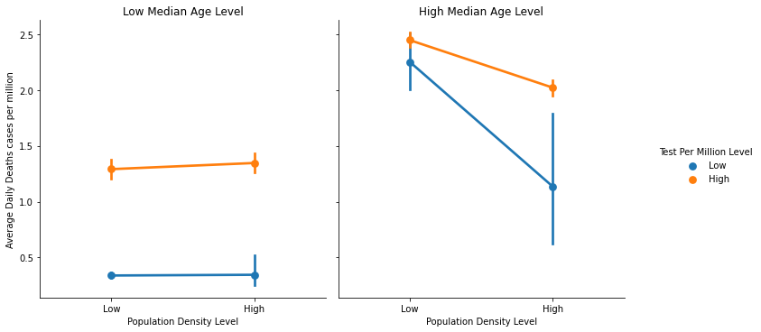

```python
g = sns.catplot(x = "pop_density_level",
            y = "daily_deaths_per_million",
            hue= "test_per_million_level",
            col = "median_age_level",
            data = timeseries_df,
            kind = "point",
            split = False,
           margin_titles=True,
        );
g.set_ylabels('Average Daily Deaths cases per million', fontsize=10);
g.set_xlabels('Population Density Level', fontsize=10);
g._legend.set_title("Test Per Million Level");
for ax, title in zip(g.axes.flat, ['Low Median Age Level', 'High Median Age Level']):
    ax.set_title(title)
```

# Observation

1 - Countries with low Median age have about the same deaths per million ratio for both population density level.

2 - For Countries with high Median we can see that deaths per million are inversly proportional to population density for both test rates.

# 5.5 Research Question5

# What is the effect of Income Level on daily cases?

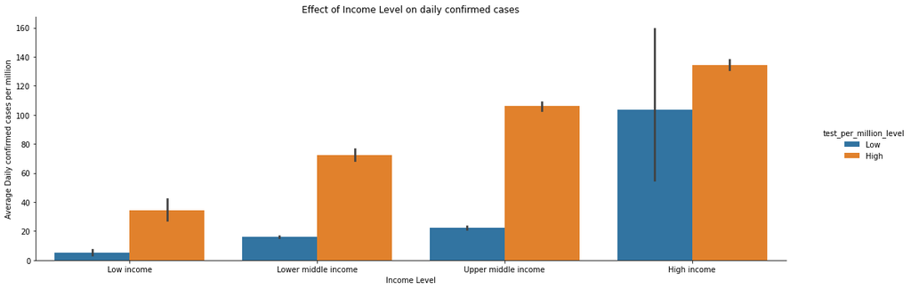

```python
sns.catplot(x = "income_level",
            y = "daily_cases_per_million",
            hue= "test_per_million_level",
            data = timeseries_df,
            kind = "bar",
#             split = False,
           margin_titles=True,
           height=5, aspect=3,order = ['Low income','Lower middle income','Upper middle income','High income']);
plt.ylabel("Average Daily confirmed cases per million");
plt.xlabel("Income Level")
plt.title("Effect of Income Level on daily confirmed cases");
```

# Observation

1 - Under all conditions, we can see the higher the income the higher the cases per million.

# 5.6 Research Question6

# What is the effect of Continent on daily cases?

```python
# step1: Create continent_df that contain total deaths ,confirmed cases and cummulative population of each continent
continent_df = timeseries_df.groupby("continent",as_index = False).sum()[["continent","daily_deaths","daily_confirmed","population"]].drop(6)

#step2: add the following columns: total_cases_per_million, total_deaths_per_million, Deaths_to_confirmed_ratio
# that we will use in the analysis
continent_df["total_cases_per_million"] = (continent_df["daily_confirmed"]/continent_df["population"])*1000000
continent_df["total_deaths_per_million"] = (continent_df["daily_deaths"]/continent_df["population"])*1000000
continent_df["Deaths_to_confirmed_ratio"] = (continent_df["daily_deaths"]/continent_df["daily_confirmed"])
# step3: rename daily_deaths and daily_confirmed to total_deaths and total_confirmed as we got the sum of these columns
#at step 1
continent_df.rename(columns = {"daily_deaths":"total_deaths","daily_confirmed":"total_confirmed"},inplace =True)
continent_df
```

|  | continent | total_deaths | total_confirmed | population | total_cases_per_million | total_deaths_per_million | Deaths_to_confirmed_ratio |
| --- | --- | --- | --- | --- | --- | --- | --- |
| 0 | Africa | 136278 | 5131055 | 701231849379 | 7.317202 | 0.194341 | 0.026559 |
| 1 | Asia | 869188 | 58358656 | 2442506200119 | 23.892941 | 0.355859 | 0.014894 |
| 2 | Europe | 980272 | 43368658 | 319083295464 | 135.916416 | 3.072151 | 0.022603 |
| 3 | North America | 894079 | 39352698 | 303754076217 | 129.554469 | 2.943430 | 0.022720 |
| 4 | Oceania | 1110 | 51392 | 21715264350 | 2.366630 | 0.051116 | 0.021599 |
| 5 | South America | 960174 | 31207198 | 222578994366 | 140.207292 | 4.313857 | 0.030768 |

```python
#create a function that take continent_df and column name nedded to be investigated and return bar plot that
# shows the difference between continents.
def continent(continent_df,column,ylabel,title):
    continent_df.sort_values(by=column,inplace=True)
    sns.catplot(x = "continent",
                y = column,
                data = continent_df,
                kind = "bar",
               margin_titles=True,
               height=5, aspect=3,order =continent_df["continent"]);

    for i in range(len(continent_df[column])):
        y_shift = continent_df[column].min()/10
        plt.text(i-0.1,continent_df[column].sort_values().values[i]+y_shift,
                 "{}".format(np.round(continent_df[column].sort_values().values[i],2)))
    plt.ylabel(ylabel)
    plt.xlabel("Continent");
    plt.title(title);
```

# 1. Cummulative confirmed cases per million

[figure not shown]

```python
continent(continent_df,"total_cases_per_million",ylabel = "Cummulative confirmed cases per million",
          title= "Cummulative confirmed cases per million in continents")
```

# 2. Cummulative deaths per million

[figure not shown]

```python
continent(continent_df,"total_deaths_per_million",ylabel = "Cummulative deaths per million",
          title= "Cummulative deaths per million in continents")
```

# 3. Deaths to confirmed cases ratio

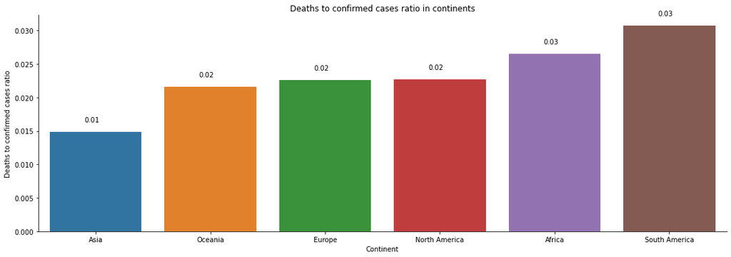

```python
continent(continent_df,"Deaths_to_confirmed_ratio",ylabel = "Deaths to confirmed cases ratio",
          title= "Deaths to confirmed cases ratio in continents")
```

# Observations

1 - we can see that even Africa has lower cases per million and deaths per million but has the second highest deaths to confirmed ratio. This can reflect the heath care of Africa.

2- South America is the most suffering continent.

3- Europe and North America reflect better heath care systems comparing their death to confirmed ratios and observing their very high cases per million

# 5.7 Research Question 7

# What is the effect of Vaccinations on daily cases?

```python
# Create a function that take the timeseries dataframe and country name then return a plot that combine
# daily confirmed cases and daily full vaccinated cases to show the effect of vaccination on daily new cases.

def vaccination(timeseries_df,country):
    fig, ax = plt.subplots(figsize=(15,8))
    country_df = timeseries_df[timeseries_df["country"] == country].copy()
    country_df["daily_full_vaccinated_per_million"] = country_df["daily_full_vaccinated_per_million"].rolling(7).mean()
    country_df["daily_cases_per_million"] = country_df["daily_cases_per_million"].rolling(7).mean()
    sns.lineplot(x = 'date', y = 'daily_cases_per_million',data = country_df,ax=ax)
    sns.lineplot(x = 'date', y = 'daily_full_vaccinated_per_million',data = country_df,ax=ax)
    plt.legend(["Daily confirmed cases per million","Daily full vaccinated per million"]);
    plt.ylabel("Daily cases per million")
    plt.xlabel("Date")
    plt.title("Effect of vaccination on  {} cases".format(country));
```

## UK

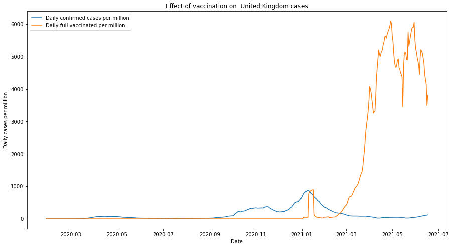

```python
vaccination(timeseries_df,"United Kingdom")
```

# United states

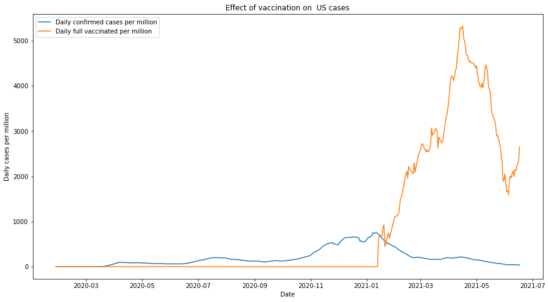

```python
vaccination(timeseries_df,"US")
```

## Observation

We don't need to fall into the faulty of generalization. So,for US and Uk we can notice a high decrease in daily cases from the start of vaccination.

# 6- Conclusions

## Timeseries Analysis

1- It is clear that the occurrence time of waves and their strength are greatly different from one country to another. We definitly can't identify a pattern that all countries follow either in wave strength or time of occurrence. we can only find few details that some countries share.

2- Worldwide data may be misleading if it took alone as different countries has very different conditions.So, we can't generalize any insights from it.

3- The strength of waves worldwide is continously incrasing but in Egypt,US and Italy the third wave is lower than the second one. This can explain point 2.

4- Egypt, United Kingdom and US shares a wave in months [Dec,Jan,Feb].

5- Egypt and Italy share a repetitive pattern of covid waves that starts between Feb and March. It happened in 2020 and also in 2021.

6- United Kingdom and India don't have repeatitive patterns in waves till now.

## Effect of Test rates on daily cases

7- There is a wide gap of test rates between countries.

8- High test rates result in increase in daily cases per million ratio. This High test rates will be the more likeliy to represent the actual case.

## Effect of Population density on daily cases

9- For low test rates it seems to have no effect.

10 - For high test rates we can see an increase in average daily cases per million for high population density.

## Effect of median age on daily cases

11- For both low test rates and high test rates we can see an increase in average daily cases per million for high median age counties but it is more clear for high test rates.

12- Countries with high Median age has higher averager deaths under all conditions.

13- Countries with low Median age have about the same deaths per million ratio for both population density level.

14- For Countries with high Median we can see that deaths per million are inversly proportional to population density for both test rates.

## Effect of Income level on daily cases

15- Under all conditions, we can see the higher the income the higher the cases per million.

## Effect of continent on daily cases

16- we can see that even Africa has lower cases per million and deaths per million but has the second highest deaths to confirmed ratio. This can reflect quality of the heath care system of Africa.

17- South America is the most suffering continent.

## Effect of vaccination on daily cases

20 - for US and Uk we can notice a high decrease in daily cases from the start of vaccination.

# 7- Recommendations

1- Countries with repeatitive wave patterns should make great use of this. They should take proactive moves designing their future strategies about food imports,medcine, etc.. taking into consideration the reasonable likelihood of being hit by a wave on the next pattern.

2- Study should be conducted to relate why high income countries has the highest cases per million, is that have any relation with the food happits, daily routine?